# EkonometriaProj

2025-06-22

### 1 Wprowadzenie

#### 1.1 Opis projektu

Projekt ma na celu budowę kompleksowego modelu ekonometrycznego służącego do analizy i prognozowania cen biletów lotniczych. Analiza obejmuje identyfikację czynników wpływających na poziom cen oraz ocenę jakości dopasowania modelu. Dane mają charakter przekrojowy i obejmują cechy połączeń lotniczych dostępnych w sprzedaży, takie jak linia lotnicza, liczba przesiadek, długość lotu czy liczba dni pozostałych do daty wylotu.

Model regresji liniowej został zbudowany w szczególności dla klasy Economy – dominującej w zestawie – przy użyciu klasycznych oraz zaawansowanych technik modelowania (m.in. interakcje zmiennych, transformacje logarytmiczne, splajny). Końcowym etapem projektu jest wykonanie predykcji cen na zbiorze testowym oraz ocena błędów predykcji.

#### 1.2 Zmienne

##### 1.2.1 Zmienna objaśniana

**price** – cena biletu lotniczego (w złotych)

#### 1.3 Źródła

https://www.kaggle.com/datasets/dhirajbembade/indian-airlines-ticket-price-analysis

#### 1.4 Biblioteki

```r
library(tidyverse)
library(strucchange)
library(caret)
library(dplyr)
library(ggplot2)
library(car)
library(lmtest)
library(tseries)
library(sandwich)
library(car)
library(mgcv)
library(readr)
library(ggcorrplot)
```

### 2 Wczytywanie danych

Dane pochodzą ze strony https://www.kaggle.com/datasets/dhirajbembade/indian-airlines-ticket-price-analysis Zawierają informacje o ponad 300 000 połączeniach lotniczych. Ze względu na dużą liczność danych, do analizy wykorzystano losową próbkę 30 000 obserwacji.

```r
df_full <- read_csv("Clean_Dataset.csv")
```

### 3 Opis i wstępna obróbka danych

```r
set.seed(123)
df <- df_full %>% sample_n(30000)
```

#### 3.1 Podstawowe statystyki

##### Sprawdzanie braków.

```
##             ...1          airline           flight      source_city
##                0                0                0                0
##   departure_time            stops     arrival_time destination_city
##                0                0                0                0
##            class         duration        days_left            price
##                0                0                0                0
```

Nie występują braki danych:)

```r
summary(df)
```

```
##       ...1          airline             flight          source_city
##  Min.   :    15   Length:30000       Length:30000       Length:30000
##  1st Qu.: 74863   Class :character   Class :character   Class :character
##  Median :149490   Mode  :character   Mode  :character   Mode  :character
##  Mean   :149962
##  3rd Qu.:224796
##  Max.   :300140
##  departure_time        stops           arrival_time       destination_city
##  Length:30000       Length:30000       Length:30000       Length:30000
##  Class :character   Class :character   Class :character   Class :character
##  Mode  :character   Mode  :character   Mode  :character   Mode  :character
##
##
##
##     class              duration       days_left         price
##  Length:30000       Min.   : 0.83   Min.   : 1.00   Min.   :  1105
##  Class :character   1st Qu.: 6.83   1st Qu.:14.00   1st Qu.:  4784
##  Mode  :character   Median :11.33   Median :26.00   Median :  7426
##                     Mean   :12.24   Mean   :25.92   Mean   : 20821
##                     3rd Qu.:16.17   3rd Qu.:38.00   3rd Qu.: 42457
##                     Max.   :45.83   Max.   :49.00   Max.   :114523
```

```r
glimpse(df)
```

```
## Rows: 30,000
## Columns: 12
## $ ...1             <dbl> 188941, 134057, 124021, 160996, 226317, 124506, 19362…
## $ airline          <chr> "Vistara", "Indigo", "Air_India", "Indigo", "Vistara"…
## $ flight           <chr> "UK-834", "6E-6488", "AI-526", "6E-5207", "UK-910", "…
## $ source_city      <chr> "Chennai", "Kolkata", "Kolkata", "Hyderabad", "Mumbai…
## $ departure_time   <chr> "Evening", "Morning", "Evening", "Morning", "Evening"…
## $ stops            <chr> "one", "one", "one", "zero", "zero", "zero", "one", "…
## $ arrival_time     <chr> "Night", "Evening", "Afternoon", "Morning", "Evening"…
## $ destination_city <chr> "Mumbai", "Mumbai", "Delhi", "Mumbai", "Delhi", "Delh…
## $ class            <chr> "Economy", "Economy", "Economy", "Economy", "Business…
## $ duration         <dbl> 6.67, 4.67, 18.83, 1.58, 2.17, 2.50, 7.33, 11.67, 6.1…
## $ days_left        <dbl> 13, 41, 29, 20, 15, 32, 48, 14, 22, 36, 22, 26, 3, 29…
## $ price            <dbl> 11783, 3381, 5061, 3096, 37932, 3999, 1830, 17388, 59…
```

Zmiennymi kategorycznymi są airline, source_city, departure_time, stops, arrival_time, destination_city oraz class – każda z nich przyjmuje skończoną liczbę wartości (np. airline to kilka nazw linii lotniczych, a stops to trzy możliwe opcje: zero, one, two_or_more). Wśród tych zmiennych widać wyraźną nierównowagę – niektóre kategorie dominują, np. Vistara w airline, Delhi w source_city czy klasa ekonomiczna w class. W przypadku departure_time i arrival_time rozkład jest bardziej zróżnicowany, ale nadal niektóre pory dnia (rano, wieczór) występują częściej.

#### 3.2 Wizualizacja danych

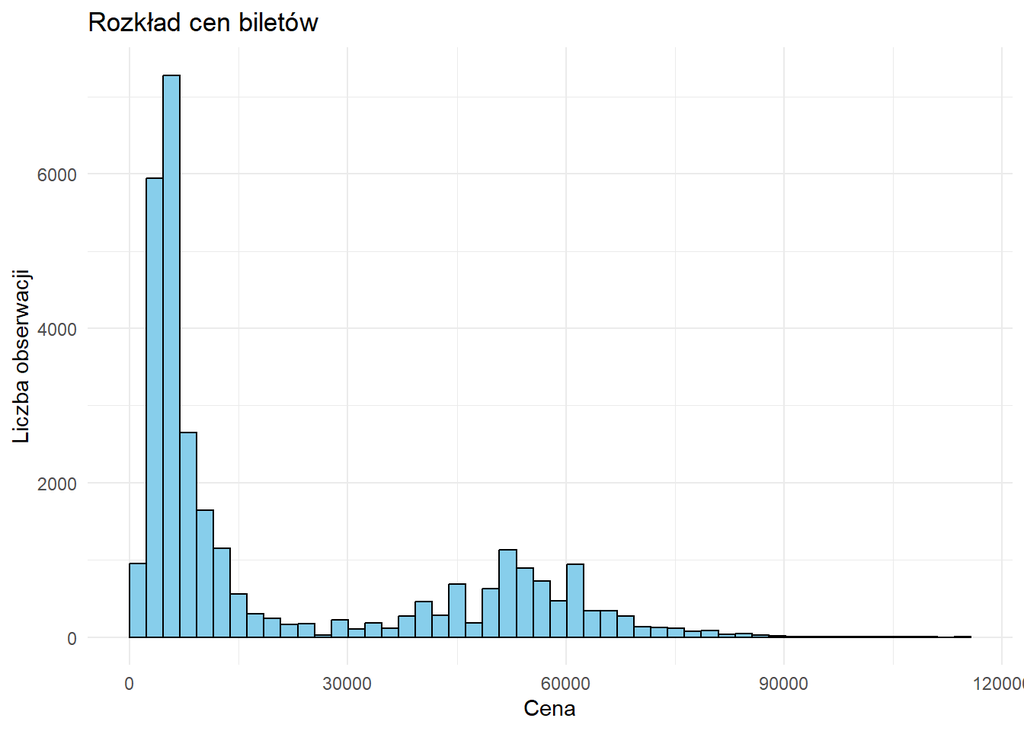

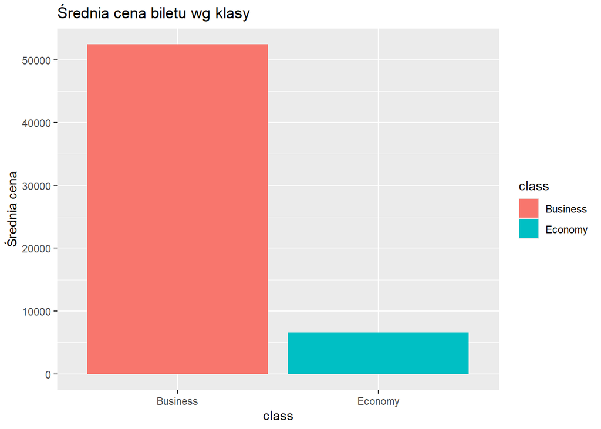

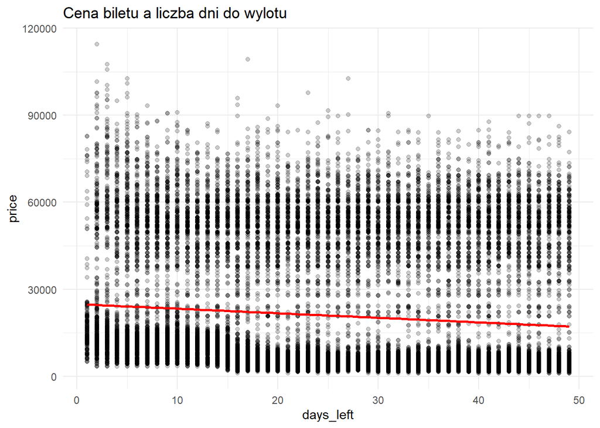

#### 3.3 Transformacja zmiennych i redukcja

Dokonano konwersji zmiennych jakościowych (`airline`, `stops`, `class`, itd.) do formatu `factor`, co jest wymagane przy modelowaniu regresji liniowej z udziałem zmiennych kategorycznych. Dodatkowo usunięto zbędne kolumny (`flight`, indeksy).

Z pomocą funkcji `select()` ograniczono zbiór do niezbędnych zmiennych, co uprościło dalsze przetwarzanie danych i budowę modelu.

Dane podzielono na zbiór treningowy (80%) oraz testowy (20%) z użyciem funkcji `createDataPartition()` z pakietu `caret`. Zapewnia to proporcjonalny podział względem zmiennej celu (`price`) i umożliwia niezależną walidację modelu.

```r
df <- df %>% mutate(across(c(airline, source_city, departure_time, stops,
                             arrival_time, destination_city, class), as.factor)) %>%
  select(2,4:12)
str(df)
```

```
## tibble [30,000 × 10] (S3: tbl_df/tbl/data.frame)
##  $ airline         : Factor w/ 6 levels "Air_India","AirAsia",..: 6 4 1 4 6 4 4 1 6 6 ...
##  $ source_city     : Factor w/ 6 levels "Bangalore","Chennai",..: 2 5 5 4 6 5 2 6 6 6 ...
##  $ departure_time  : Factor w/ 6 levels "Afternoon","Early_Morning",..: 3 5 3 5 3 2 5 2 5 2 ...
##  $ stops           : Factor w/ 3 levels "one","two_or_more",..: 1 1 1 3 3 3 1 1 1 1 ...
##  $ arrival_time    : Factor w/ 6 levels "Afternoon","Early_Morning",..: 6 3 1 5 3 2 3 3 3 6 ...
##  $ destination_city: Factor w/ 6 levels "Bangalore","Chennai",..: 6 6 3 6 3 3 6 3 5 1 ...
##  $ class           : Factor w/ 2 levels "Business","Economy": 2 2 2 2 1 2 2 2 2 2 ...
##  $ duration        : num [1:30000] 6.67 4.67 18.83 1.58 2.17 ...
##  $ days_left       : num [1:30000] 13 41 29 20 15 32 48 14 22 36 ...
##  $ price           : num [1:30000] 11783 3381 5061 3096 37932 ...
```

```r
set.seed(123)  # powtarzalność
train_index <- createDataPartition(df$price, p = 0.8, list = FALSE)

train_df <- df[train_index, ]
test_df  <- df[-train_index, ]
```

#### 3.3 Macierz korelacji

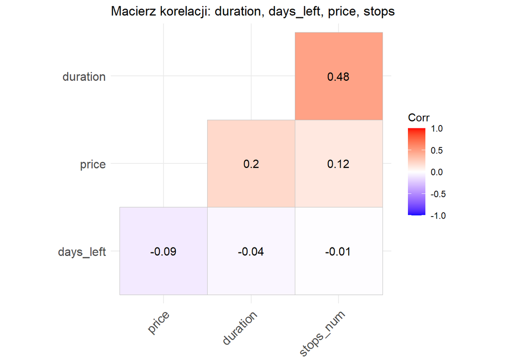

```r
df <- df %>%
  mutate(stops_num = case_when(
    stops == "zero" ~ 0,
    stops == "one" ~ 1,
    stops == "two_or_more" ~ 2
  ))

cor_mat <- df %>%
  select(duration, days_left, price, stops_num) %>%
  cor(use = "pairwise.complete.obs")

if (!require(ggcorrplot)) install.packages("ggcorrplot")

ggcorrplot(cor_mat,
           hc.order = TRUE,
           type = "lower",
           lab = TRUE,
           title = "Macierz korelacji: duration, days_left, price, stops")
```

Największy wpływ na czas trwania lotu ma liczba przesiadek, a na cenę – czas trwania lotu. Liczba dni do wylotu nie wpływa znacząco na pozostałe cechy. Ogólnie korelacje nie są bardzo wysokie, więc żadne z tych zmiennych nie są ze sobą silnie powiązane, poza logicznym związkiem między przesiadkami a długością podróży.

### 4 Budowa Modelu Ekonometrycznego

#### 4.1 Budowa modelu bazowego

```r
model <- lm(price ~ airline + class + stops + duration + days_left, data = train_df)
summary(model)
```

```
##
## Call:
## lm(formula = price ~ airline + class + stops + duration + days_left,
##     data = train_df)
##
## Residuals:
##    Min     1Q Median     3Q    Max
## -30158  -3025   -509   3171  56388
##
## Coefficients:
##                    Estimate Std. Error  t value Pr(>|t|)
## (Intercept)       53162.961    189.384  280.715  < 2e-16 ***
## airlineAirAsia     -176.528    220.129   -0.802    0.423
## airlineGO_FIRST    1571.979    195.222    8.052 8.50e-16 ***
## airlineIndigo      2239.174    167.007   13.408  < 2e-16 ***
## airlineSpiceJet    2562.844    273.212    9.380  < 2e-16 ***
## airlineVistara     4024.945    111.398   36.131  < 2e-16 ***
## classEconomy     -44865.494    109.012 -411.565  < 2e-16 ***
## stopstwo_or_more   2339.936    225.437   10.380  < 2e-16 ***
## stopszero         -8025.907    162.393  -49.423  < 2e-16 ***
## duration             53.784      8.119    6.624 3.56e-11 ***
## days_left          -131.774      3.291  -40.046  < 2e-16 ***
## ---
## Signif. codes:  0 '***' 0.001 '**' 0.01 '*' 0.05 '.' 0.1 ' ' 1
##
## Residual standard error: 6900 on 23991 degrees of freedom
## Multiple R-squared:  0.9071, Adjusted R-squared:  0.9071
## F-statistic: 2.344e+04 on 10 and 23991 DF,  p-value: < 2.2e-16
```

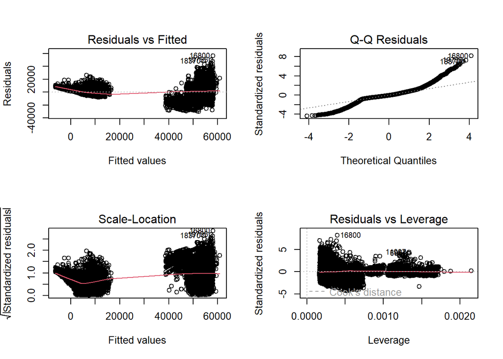

```r
par(mfrow = c(2, 2))
plot(model)
```

Na początku zbudowano podstawowy model regresji liniowej dla całego zbioru treningowego. Zmienną objaśnianą była cena biletu (`price`), a zmiennymi objaśniającymi: linia lotnicza, klasa biletu, liczba przesiadek, długość lotu oraz liczba dni do wylotu.

#### 4.2 Test Chowa

```r
table(df$class)
```

```
##
## Business  Economy
##     9304    20696
```

```r
# Sortujemy dane
train_df <- train_df %>% arrange(class)
split_point <- which(train_df$class == "Economy")[1]  # pierwszy wiersz klasy Economy

# Model pełny
model_chow <- lm(price ~ airline + stops + duration + days_left + arrival_time, data = train_df)

# Test Chowa
chow_result <- sctest(model_chow, type = "Chow", point = split_point)
chow_result
```

```
##
##  M-fluctuation test
##
## data:  model_chow
## f(efp) = 42.781, p-value < 2.2e-16
```

#### 4.3 Model regresji dla klasy Economy

```r
train_economy  <- train_df %>% filter(class == "Economy")
test_economy <- test_df %>% filter(class == "Economy")
model_economy  <- lm(price ~ airline + stops + duration + days_left, data = train_economy)
summary(model_economy)
```

```
##
## Call:
## lm(formula = price ~ airline + stops + duration + days_left,
##     data = train_economy)
##
## Residuals:
##     Min      1Q  Median      3Q     Max
## -6337.9 -1766.0  -340.7  1234.6 24685.0
##
## Coefficients:
##                  Estimate Std. Error t value Pr(>|t|)
## (Intercept)      10682.68      90.42 118.138  < 2e-16 ***
## airlineAirAsia   -2673.94      90.96 -29.398  < 2e-16 ***
## airlineGO_FIRST   -898.93      81.53 -11.026  < 2e-16 ***
## airlineIndigo    -1053.55      72.82 -14.468  < 2e-16 ***
## airlineSpiceJet   -779.69     109.88  -7.096 1.34e-12 ***
## airlineVistara     561.10      58.34   9.618  < 2e-16 ***
## stopstwo_or_more  1980.85      92.52  21.411  < 2e-16 ***
## stopszero        -2166.16      73.30 -29.550  < 2e-16 ***
## duration            30.71       3.96   7.755 9.36e-15 ***
## days_left         -149.17       1.56 -95.625  < 2e-16 ***
## ---
## Signif. codes:  0 '***' 0.001 '**' 0.01 '*' 0.05 '.' 0.1 ' ' 1
##
## Residual standard error: 2711 on 16543 degrees of freedom
## Multiple R-squared:  0.472,  Adjusted R-squared:  0.4717
## F-statistic:  1643 on 9 and 16543 DF,  p-value: < 2.2e-16
```

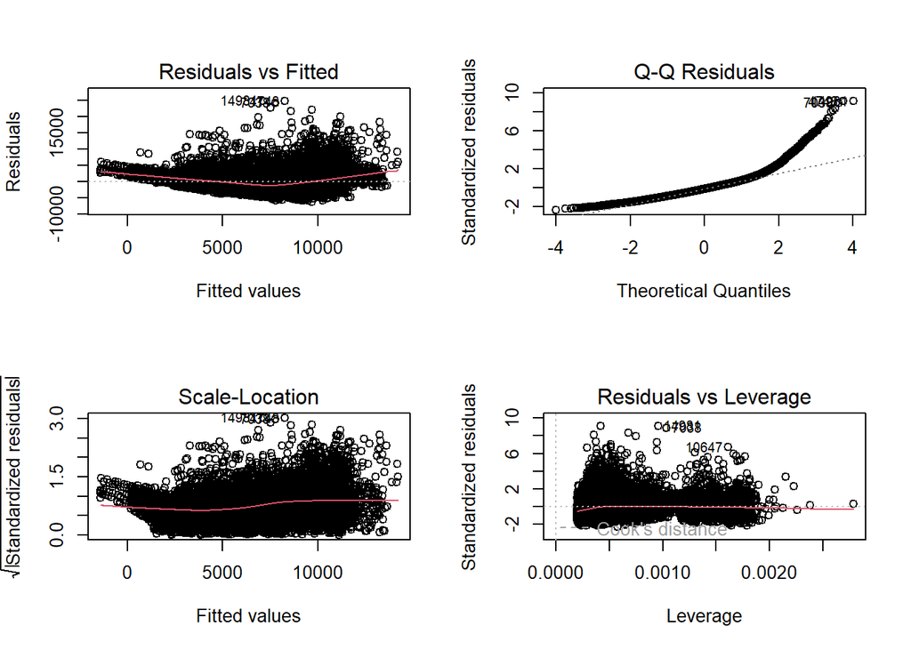

```r
par(mfrow = c(2, 2))
plot(model_economy)
```

Ograniczono się do obserwacji klasy Economy. Na tym zbiorze zbudowano model regresji liniowej z podstawowymi zmiennymi wyjaśniającymi. Wykresy diagnostyczne nadal wskazywały na możliwe odstępstwa od założeń, m.in. obecność outlierów oraz nieliniowość.

#### 4.4 Interakcje między linią lotniczą a przesiadkami

```r
train_economy %>%
  group_by(airline, stops) %>%
  summarise(mean_price = mean(price), .groups = "drop") %>%
  arrange(desc(mean_price))
```

```
## # A tibble: 17 × 3
##    airline   stops       mean_price
##    <fct>     <fct>            <dbl>
##  1 Air_India two_or_more     10822.
##  2 Vistara   two_or_more     10339.
##  3 Vistara   one              7886.
##  4 Indigo    two_or_more      7711.
##  5 Air_India one              7306.
##  6 SpiceJet  one              6815.
##  7 GO_FIRST  two_or_more      6417.
##  8 GO_FIRST  one              6016.
##  9 Indigo    one              5880.
## 10 AirAsia   two_or_more      4825.
## 11 SpiceJet  zero             4424.
## 12 Vistara   zero             4187.
## 13 AirAsia   one              4028.
## 14 Indigo    zero             3975.
## 15 Air_India zero             3921.
## 16 GO_FIRST  zero             3734.
## 17 AirAsia   zero             3716.
```

```r
model_economy1  <- lm(price ~ airline * stops + duration + days_left, data =train_economy)
summary(model_economy1)
```

```
##
## Call:
## lm(formula = price ~ airline * stops + duration + days_left,
##     data = train_economy)
##
## Residuals:
##     Min      1Q  Median      3Q     Max
## -6252.5 -1735.1  -314.5  1218.0 24830.7
##
## Coefficients: (1 not defined because of singularities)
##                                   Estimate Std. Error t value Pr(>|t|)
## (Intercept)                      10892.484     93.288 116.762  < 2e-16 ***
## airlineAirAsia                   -2875.243    103.320 -27.828  < 2e-16 ***
## airlineGO_FIRST                   -951.511     87.099 -10.924  < 2e-16 ***
## airlineIndigo                    -1273.673     80.991 -15.726  < 2e-16 ***
## airlineSpiceJet                   -762.924    125.510  -6.079 1.24e-09 ***
## airlineVistara                     550.329     62.310   8.832  < 2e-16 ***
## stopstwo_or_more                  2379.070    171.456  13.876  < 2e-16 ***
## stopszero                        -3026.472    181.691 -16.657  < 2e-16 ***
## duration                            20.416      4.052   5.039 4.72e-07 ***
## days_left                         -149.623      1.547 -96.706  < 2e-16 ***
## airlineAirAsia:stopstwo_or_more  -1775.339    272.084  -6.525 7.00e-11 ***
## airlineGO_FIRST:stopstwo_or_more -3322.336    530.901  -6.258 4.00e-10 ***
## airlineIndigo:stopstwo_or_more    -768.605    419.282  -1.833  0.06680 .
## airlineSpiceJet:stopstwo_or_more        NA         NA      NA       NA
## airlineVistara:stopstwo_or_more    298.132    219.779   1.357  0.17496
## airlineAirAsia:stopszero          2905.468    274.357  10.590  < 2e-16 ***
## airlineGO_FIRST:stopszero          816.004    254.515   3.206  0.00135 **
## airlineIndigo:stopszero           1202.574    204.610   5.877 4.25e-09 ***
## airlineSpiceJet:stopszero          568.860    277.912   2.047  0.04068 *
## airlineVistara:stopszero          -441.071    220.120  -2.004  0.04511 *
## ---
## Signif. codes:  0 '***' 0.001 '**' 0.01 '*' 0.05 '.' 0.1 ' ' 1
##
## Residual standard error: 2683 on 16534 degrees of freedom
## Multiple R-squared:  0.4832, Adjusted R-squared:  0.4826
## F-statistic: 858.8 on 18 and 16534 DF,  p-value: < 2.2e-16
```

#### 4.5 Wpływ godziny przylotu

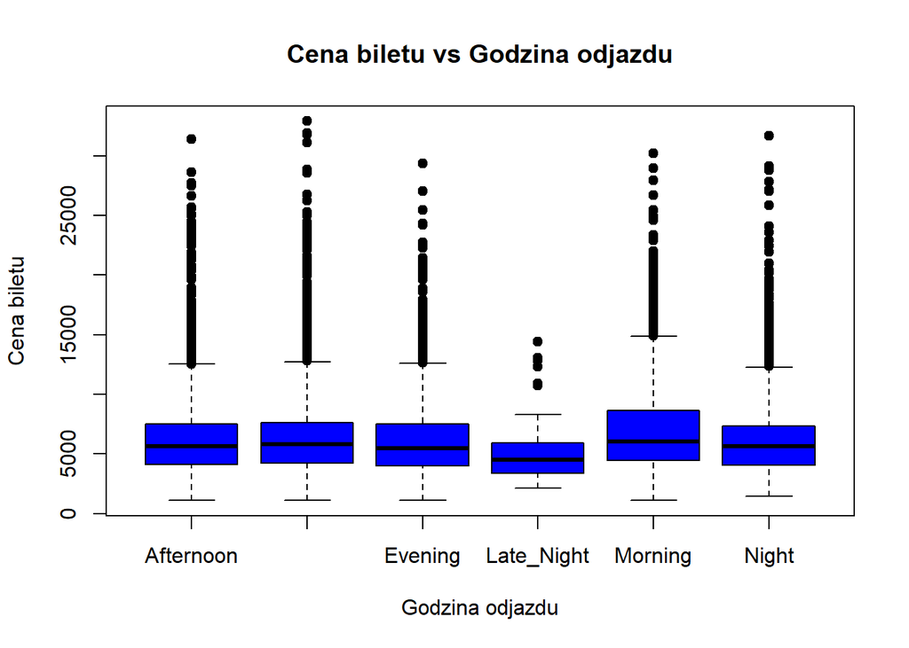

```r
plot(train_economy$departure_time,
     train_economy$price,
     main = "Cena biletu vs Godzina odjazdu",
     xlab = "Godzina odjazdu",
     ylab = "Cena biletu",
     pch = 19,       # punkt jako pełne kółko
     col = "blue")   # kolor punktów
```

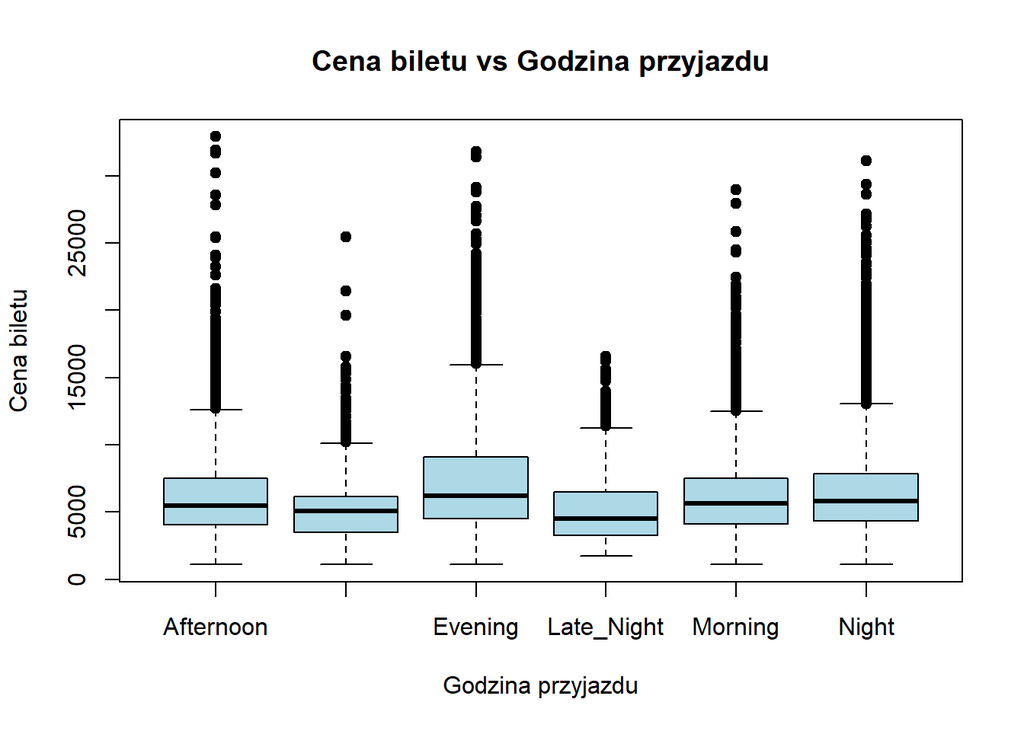

```r
# Wykres 2: Cena w zależności od godziny przyjazdu
plot(train_economy$arrival_time,
     train_economy$price,
     main = "Cena biletu vs Godzina przyjazdu",
     xlab = "Godzina przyjazdu",
     ylab = "Cena biletu",
     pch = 19,
     col = "lightblue")
```

W kolejnym kroku do modelu dodano zmienną `arrival_time`, czyli godzinę przylotu. Celem było sprawdzenie, czy pora zakończenia podróży wpływa na cenę biletu.

```r
model_economy2  <- lm(price ~ airline * stops + duration + days_left +arrival_time , data = train_economy)
summary(model_economy2)
```

```
##
## Call:
## lm(formula = price ~ airline * stops + duration + days_left +
##     arrival_time, data = train_economy)
##
## Residuals:
##     Min      1Q  Median      3Q     Max
## -6305.6 -1702.1  -311.3  1209.7 24458.0
##
## Coefficients: (1 not defined because of singularities)
##                                   Estimate Std. Error t value Pr(>|t|)
## (Intercept)                      10903.414    105.755 103.101  < 2e-16 ***
## airlineAirAsia                   -2797.319    103.724 -26.969  < 2e-16 ***
## airlineGO_FIRST                   -882.549     87.249 -10.115  < 2e-16 ***
## airlineIndigo                    -1306.850     80.652 -16.203  < 2e-16 ***
## airlineSpiceJet                   -716.241    124.695  -5.744 9.41e-09 ***
## airlineVistara                     519.894     62.040   8.380  < 2e-16 ***
## stopstwo_or_more                  2391.912    170.304  14.045  < 2e-16 ***
## stopszero                        -2884.142    180.809 -15.951  < 2e-16 ***
## duration                            26.408      4.074   6.481 9.35e-11 ***
## days_left                         -149.338      1.537 -97.159  < 2e-16 ***
## arrival_timeEarly_Morning         -896.572    104.222  -8.602  < 2e-16 ***
## arrival_timeEvening                300.923     71.018   4.237 2.27e-05 ***
## arrival_timeLate_Night            -104.246    104.518  -0.997  0.31859
## arrival_timeMorning               -460.511     74.553  -6.177 6.69e-10 ***
## arrival_timeNight                  -93.233     68.786  -1.355  0.17530
## airlineAirAsia:stopstwo_or_more  -1824.583    270.448  -6.747 1.56e-11 ***
## airlineGO_FIRST:stopstwo_or_more -3319.132    527.340  -6.294 3.17e-10 ***
## airlineIndigo:stopstwo_or_more    -820.727    416.536  -1.970  0.04881 *
## airlineSpiceJet:stopstwo_or_more        NA         NA      NA       NA
## airlineVistara:stopstwo_or_more    208.834    218.358   0.956  0.33889
## airlineAirAsia:stopszero          2815.251    272.559  10.329  < 2e-16 ***
## airlineGO_FIRST:stopszero          728.038    252.860   2.879  0.00399 **
## airlineIndigo:stopszero           1229.566    203.269   6.049 1.49e-09 ***
## airlineSpiceJet:stopszero          606.327    276.171   2.195  0.02814 *
## airlineVistara:stopszero          -464.118    218.629  -2.123  0.03378 *
## ---
## Signif. codes:  0 '***' 0.001 '**' 0.01 '*' 0.05 '.' 0.1 ' ' 1
##
## Residual standard error: 2664 on 16529 degrees of freedom
## Multiple R-squared:  0.4904, Adjusted R-squared:  0.4897
## F-statistic: 691.7 on 23 and 16529 DF,  p-value: < 2.2e-16
```

Włączenie tej zmiennej poprawiło dopasowanie modelu.

#### 4.6 Transformacja zmiennej zależnej (logarytm)

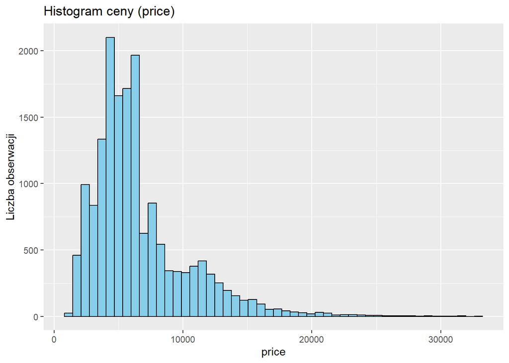

```r
train_economy <- train_economy %>%
  mutate(log_price = log(price))

# Histogram ceny
ggplot(train_economy, aes(x = price)) +
  geom_histogram(bins = 50, fill = "skyblue", color = "black") +
  labs(title = "Histogram ceny (price)", x = "price", y = "Liczba obserwacji")
```

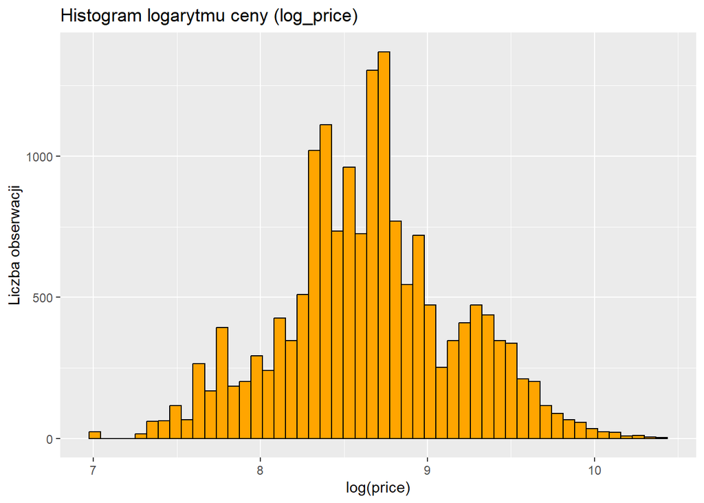

```r
# Histogram log_ceny
ggplot(train_economy, aes(x = log_price)) +
  geom_histogram(bins = 50, fill = "orange", color = "black") +
  labs(title = "Histogram logarytmu ceny (log_price)", x = "log(price)", y = "Liczba obserwacji")
```

```r
model_log <- lm(log_price ~ airline + stops + duration + days_left + arrival_time, data = train_economy)
summary(model_log)
```

```
##
## Call:
## lm(formula = log_price ~ airline + stops + duration + days_left +
##     arrival_time, data = train_economy)
##
## Residuals:
##      Min       1Q   Median       3Q      Max
## -1.40244 -0.22805  0.00062  0.22810  1.69950
##
## Coefficients:
##                             Estimate Std. Error  t value Pr(>|t|)
## (Intercept)                9.2324484  0.0134804  684.878  < 2e-16 ***
## airlineAirAsia            -0.5073770  0.0119340  -42.515  < 2e-16 ***
## airlineGO_FIRST           -0.0874927  0.0106504   -8.215 2.28e-16 ***
## airlineIndigo             -0.1964629  0.0094593  -20.769  < 2e-16 ***
## airlineSpiceJet           -0.0563677  0.0142348   -3.960 7.53e-05 ***
## airlineVistara             0.0903923  0.0075740   11.935  < 2e-16 ***
## stopstwo_or_more           0.2432706  0.0119886   20.292  < 2e-16 ***
## stopszero                 -0.3966099  0.0095848  -41.379  < 2e-16 ***
## duration                   0.0053610  0.0005199   10.312  < 2e-16 ***
## days_left                 -0.0202592  0.0002019 -100.331  < 2e-16 ***
## arrival_timeEarly_Morning -0.1204773  0.0137090   -8.788  < 2e-16 ***
## arrival_timeEvening        0.0467864  0.0093419    5.008 5.55e-07 ***
## arrival_timeLate_Night    -0.0008018  0.0137415   -0.058    0.953
## arrival_timeMorning       -0.0551935  0.0098105   -5.626 1.87e-08 ***
## arrival_timeNight         -0.0065756  0.0090511   -0.726    0.468
## ---
## Signif. codes:  0 '***' 0.001 '**' 0.01 '*' 0.05 '.' 0.1 ' ' 1
##
## Residual standard error: 0.3508 on 16538 degrees of freedom
## Multiple R-squared:  0.5526, Adjusted R-squared:  0.5523
## F-statistic:  1459 on 14 and 16538 DF,  p-value: < 2.2e-16
```

Zmienna `price` charakteryzowała się prawoskośnym rozkładem. W celu poprawy normalności i stabilności wariancji, dokonano logarytmizacji ceny (`log(price)`). Histogramy potwierdziły, że transformacja poprawia symetrię rozkładu. Następnie zbudowano model regresji dla `log_price`, co pozwoliło na interpretację współczynników jako procentowych zmian ceny.

#### 4.7 Testowanie transformacji zmiennych liczbowych

```r
duration_vars <- list(
  linear = "duration",
  log = "log(duration)",
  pow2 = "I(duration^2)",
  pow3 = "I(duration^3)"
)

days_vars <- list(
  linear = "days_left",
  log = "log(days_left + 1)",
  pow2 = "I(days_left^2)",
  pow3 = "I(days_left^3)"
)

test_model <- function(dur, day) {
  fmla_text <- paste("log(price) ~ airline * stops +", duration_vars[[dur]], "+", days_vars[[day]], "+ arrival_time")
  model <- lm(as.formula(fmla_text), data = train_economy)

  tibble(
    duration = dur,
    days_left = day,
    adj_r2 = round(summary(model)$adj.r.squared, 4),
    reset_p = round(resettest(model, power = 2:3, type = "regressor")$p.value, 4)
  )
}

results <- expand.grid(dur = names(duration_vars), day = names(days_vars), stringsAsFactors = FALSE) %>%
  rowwise() %>%
  do(test_model(.$dur, .$day)) %>%
  ungroup()

print(results %>% arrange(desc(adj_r2)))
```

```
## # A tibble: 16 × 4
##    duration days_left adj_r2 reset_p
##    <chr>    <chr>      <dbl>   <dbl>
##  1 log      log        0.614       0
##  2 linear   log        0.611       0
##  3 pow2     log        0.610       0
##  4 pow3     log        0.610       0
##  5 log      linear     0.569       0
##  6 linear   linear     0.566       0
##  7 pow3     linear     0.565       0
##  8 pow2     linear     0.565       0
##  9 log      pow2       0.498       0
## 10 linear   pow2       0.494       0
## 11 pow3     pow2       0.494       0
## 12 pow2     pow2       0.494       0
## 13 log      pow3       0.448       0
## 14 linear   pow3       0.444       0
## 15 pow3     pow3       0.444       0
## 16 pow2     pow3       0.444       0
```

Aby lepiej uchwycić zależności między zmiennymi liczbowymi a ceną, przetestowano różne przekształcenia zmiennych `duration` oraz `days_left` (m.in. logarytmy, kwadraty i sześciany). Dla każdej kombinacji obliczono `adjusted R²` oraz przeprowadzono test RESET. Najlepsze rezultaty osiągnięto dla logarytmicznej transformacji obu zmiennych.

#### 4.8 Wizualna ocena transformacji

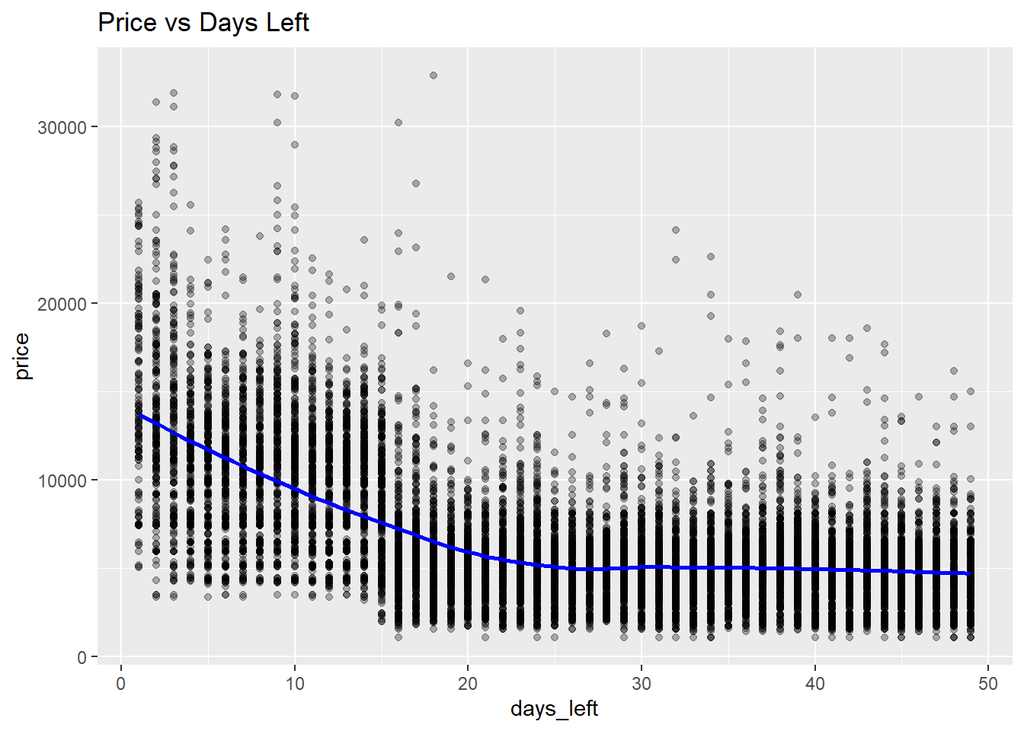

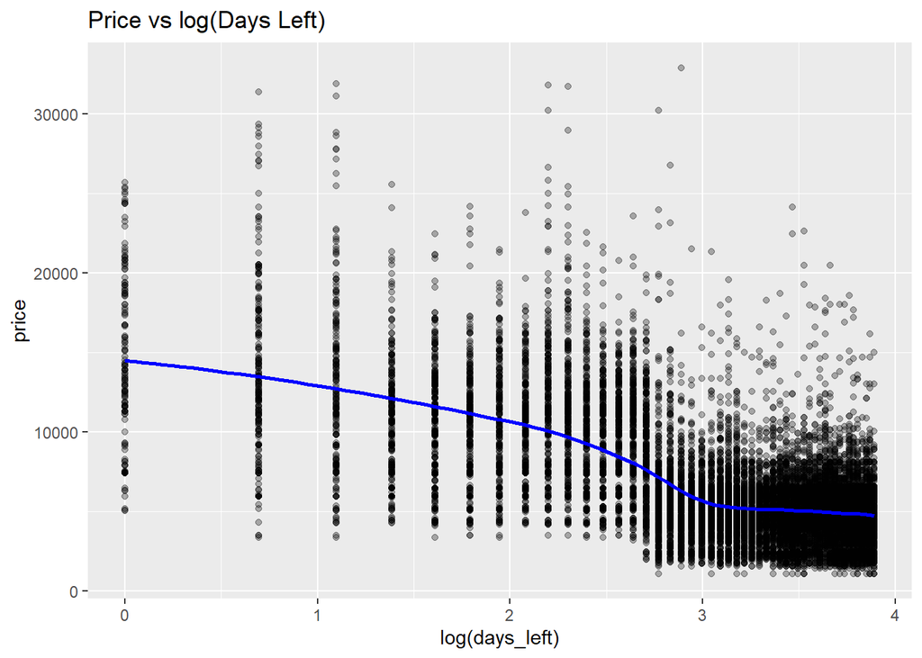

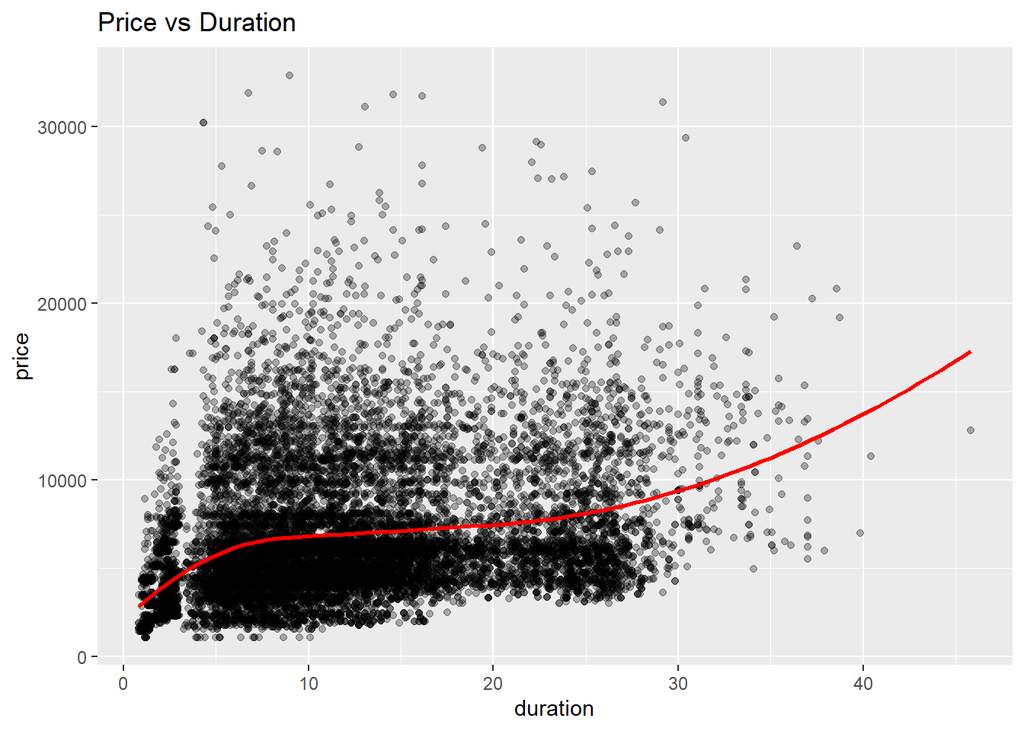

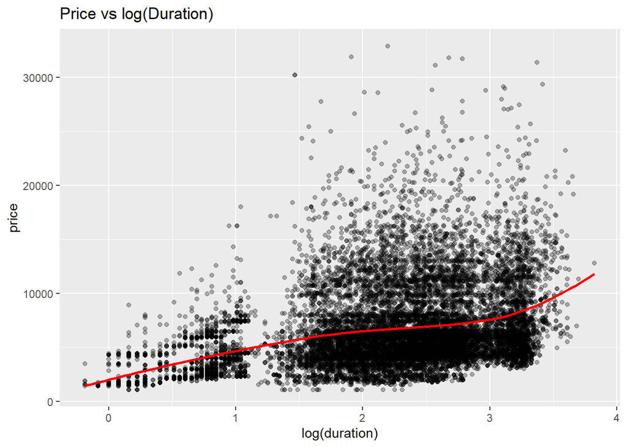

```r
p1 <- ggplot(train_economy, aes(x = days_left, y = price)) +
  geom_point(alpha = 0.3) +
  geom_smooth(method = "loess", se = FALSE, color = "blue") +
  labs(title = "Price vs Days Left")
p2 <- ggplot(train_economy, aes(x = log(days_left), y = price)) +
  geom_point(alpha = 0.3) +
  geom_smooth(method = "loess", se = FALSE, color = "blue") +
  labs(title = "Price vs log(Days Left)")

p3 <- ggplot(train_economy, aes(x = duration, y = price)) +
  geom_point(alpha = 0.3) +
  geom_smooth(method = "loess", se = FALSE, color = "red") +
  labs(title = "Price vs Duration")
p4 <- ggplot(train_economy, aes(x = log(duration), y = price)) +
  geom_point(alpha = 0.3) +
  geom_smooth(method = "loess", se = FALSE, color = "red") +
  labs(title = "Price vs log(Duration)")

print(p1); print(p2); print(p3); print(p4)
```